# Tugas Praktikum Pertemuan 3 MPDW

# Library

```r
library(dLagM)
library(dynlm)
library(MLmetrics)
library(lmtest)
library(car)
```

# Nomor 1: Market Share vs Price

## 1. Impor & Pembagian Data

```r
dt_market <- data.frame(
  Periode = 1:20,
  MarketShare = c(3.63, 4.20, 3.33, 4.54, 2.89, 4.87, 4.90, 5.29, 6.18, 7.20,
                  7.25, 6.09, 6.80, 8.65, 8.43, 8.29, 7.18, 7.90, 8.45, 8.23),
  Price = c(0.97, 0.95, 0.99, 0.91, 0.98, 0.90, 0.89, 0.86, 0.85, 0.82,
            0.79, 0.83, 0.81, 0.77, 0.76, 0.80, 0.83, 0.79, 0.76, 0.78)
)

head(dt_market)
```

```
##   Periode MarketShare Price
## 1       1        3.63  0.97
## 2       2        4.20  0.95
## 3       3        3.33  0.99
## 4       4        4.54  0.91
## 5       5        2.89  0.98
## 6       6        4.87  0.90
```

```r
# Data Splitting
mkt_train <- dt_market[1:15,]
mkt_test <- dt_market[16:20,]

# Konversi ke Format Time Series
ts_train_mkt <- ts(mkt_train)
ts_test_mkt <- ts(mkt_test)
ts_mkt <- ts(dt_market)
```

## 2. Pemodelan Lag Terdistribusi

### 2.1 Model Koyck

#### Pemodelan

```r
mdl_koyck <- koyckDlm(x = mkt_train$Price, y = mkt_train$MarketShare)
summary(mdl_koyck)
```

```
##
## Call:
## "Y ~ (Intercept) + Y.1 + X.t"
##
## Residuals:
##     Min      1Q  Median      3Q     Max
## -0.9997 -0.3171  0.0652  0.2586  1.1063
##
## Coefficients:
##             Estimate Std. Error t value Pr(>|t|)
## (Intercept)  15.4328    14.7611   1.046    0.318
## Y.1           0.3651     0.5152   0.709    0.493
## X.t         -13.4703    13.8869  -0.970    0.353
##
## Residual standard error: 0.599 on 11 degrees of freedom
## Multiple R-Squared: 0.9037,  Adjusted R-squared: 0.8861
## Wald test: 37.92 on 2 and 11 DF,  p-value: 1.16e-05
##
## Diagnostic tests:
## NULL
##
##                             alpha      beta       phi
## Geometric coefficients:  24.30938 -13.47028 0.3651498
```

#### Akurasi Model Koyck

```r
fc_koyck <- forecast(model = mdl_koyck, x = mkt_test$Price, h = 5)
mape_koyck <- MAPE(fc_koyck$forecasts, mkt_test$MarketShare)

cat("MAPE Testing:", mape_koyck, "\n")
```

```
## MAPE Testing: 0.05312954
```

```r
GoF(mdl_koyck) # Akurasi Training
```

```
##            n       MAE         MPE       MAPE      sMAPE      MASE       MSE
## mdl_koyck 14 0.4215632 -0.01898878 0.08448088 0.08112884 0.4555545 0.2818772
##               MRAE     GMRAE
## mdl_koyck 1.457091 0.5463437
```

### 2.2 Model Distributed Lag (DLM) (Lag = 2)

#### Pemodelan

```r
mdl_dlm_2 <- dlm(x = mkt_train$Price, y = mkt_train$MarketShare, q = 2)
summary(mdl_dlm_2)
```

```
##
## Call:
## lm(formula = model.formula, data = design)
##
## Residuals:
##      Min       1Q   Median       3Q      Max
## -0.55526 -0.24858 -0.08971  0.20176  0.65633
##
## Coefficients:
##              Estimate Std. Error t value Pr(>|t|)
## (Intercept)  26.29549    1.69541  15.510 8.44e-08 ***
## x.t         -24.13651    4.05335  -5.955 0.000214 ***
## x.1          -0.00163    3.20631  -0.001 0.999606
## x.2           0.34290    4.21417   0.081 0.936929
## ---
## Signif. codes:  0 '***' 0.001 '**' 0.01 '*' 0.05 '.' 0.1 ' ' 1
##
## Residual standard error: 0.4366 on 9 degrees of freedom
## Multiple R-squared:  0.9553, Adjusted R-squared:  0.9404
## F-statistic: 64.06 on 3 and 9 DF,  p-value: 2.151e-06
##
## AIC and BIC values for the model:
##        AIC     BIC
## 1 20.56206 23.3868
```

#### Akurasi

```r
fc_dlm_2 <- forecast(model = mdl_dlm_2, x = mkt_test$Price, h = 5)
mape_dlm2 <- MAPE(fc_dlm_2$forecasts, mkt_test$MarketShare)

cat("MAPE Testing:", mape_dlm2, "\n")
```

```
## MAPE Testing: 0.0705934
```

### 2.3 DLM dengan Lag Optimum

#### Pencarian Lag Optimal

Pencarian lag optimal dilakukan secara iteratif menggunakan nilai Akaike Information Criterion (AIC) terkecil.

```r
finiteDLMauto(formula = MarketShare ~ Price,
              data = data.frame(mkt_train), q.min = 1, q.max = 10,
              model.type = "dlm", error.type = "AIC", trace = TRUE)
```

```
##    q - k    MASE      AIC      BIC   GMRAE    MBRAE R.Adj.Sq  Ljung-Box
## 7      7 0.00000     -Inf     -Inf 0.00000  0.00000      NaN        NaN
## 8      8 0.00000     -Inf     -Inf 0.00000  0.00000      NaN        NaN
## 9      9 0.00000     -Inf     -Inf 0.00000  0.00000      NaN        NaN
## 10    10 0.00000     -Inf     -Inf 0.00000  0.00000      NaN        NaN
## 6      6 0.08453 -4.06421 -2.28919 0.11903 -0.33129  0.97249 0.04562035
## 3      3 0.27946 14.41990 17.32934 0.49694 -0.34334  0.95685 0.87839563
## 5      5 0.30204 15.91911 18.33979 0.49375 -0.33012  0.89375 0.34730411
## 4      4 0.29388 16.21356 18.99882 0.48458 -0.05971  0.94508 0.68007694
## 1      1 0.35387 19.92429 22.48052 0.47815  1.13162  0.94457 0.32743011
## 2      2 0.32363 20.56206 23.38680 0.35152 -0.40855  0.94035 0.68818708
```

Lag optimum didapatkan ketika lag $q = 6$ karena menghasilkan nilai AIC yang paling minimal, yaitu sebesar -4.06421.

#### Pemodelan

```r
mdl_dlm_opt <- dlm(x = mkt_train$Price, y = mkt_train$MarketShare, q = 6)
summary(mdl_dlm_opt)
```

```
##
## Call:
## lm(formula = model.formula, data = design)
##
## Residuals:
##        1        2        3        4        5        6        7        8
## -0.06257  0.05379  0.06679 -0.05236 -0.03731  0.04871 -0.07404  0.12979
##        9
## -0.07279
##
## Coefficients:
##             Estimate Std. Error t value Pr(>|t|)
## (Intercept)  37.4332     2.7496  13.614   0.0467 *
## x.t         -43.9959     5.1527  -8.538   0.0742 .
## x.1           1.3336     4.4868   0.297   0.8161
## x.2           0.6599     2.9610   0.223   0.8604
## x.3           0.3176     3.5214   0.090   0.9427
## x.4          16.6181     5.4842   3.030   0.2029
## x.5           1.3711     3.0017   0.457   0.7272
## x.6         -13.6131     4.2894  -3.174   0.1943
## ---
## Signif. codes:  0 '***' 0.001 '**' 0.01 '*' 0.05 '.' 0.1 ' ' 1
##
## Residual standard error: 0.2131 on 1 degrees of freedom
## Multiple R-squared:  0.9966, Adjusted R-squared:  0.9725
## F-statistic:  41.4 on 7 and 1 DF,  p-value: 0.1191
##
## AIC and BIC values for the model:
##         AIC       BIC
## 1 -4.064207 -2.289185
```

```r
# Akurasi DLM Optimum
fc_dlm_opt <- forecast(model = mdl_dlm_opt, x = mkt_test$Price, h = 5)
mape_dlm_opt <- MAPE(fc_dlm_opt$forecasts, mkt_test$MarketShare)
cat("MAPE Testing:", mape_dlm_opt, "\n")
```

```
## MAPE Testing: 0.06368703
```

### 2.4 Model Autoregressive Distributed Lag (ARDL) - Ordo (1,1)

#### Pemodelan

```r
mdl_ardl <- ardlDlm(formula = MarketShare ~ Price, data = mkt_train, p = 1, q = 1)
summary(mdl_ardl)
```

```
##
## Time series regression with "ts" data:
## Start = 2, End = 15
##
## Call:
## dynlm(formula = as.formula(model.text), data = data)
##
## Residuals:
##      Min       1Q   Median       3Q      Max
## -0.50247 -0.30360 -0.05952  0.31335  0.74004
##
## Coefficients:
##               Estimate Std. Error t value Pr(>|t|)
## (Intercept)    18.1366     7.7391   2.344   0.0411 *
## Price.t       -23.5593     2.8404  -8.294 8.57e-06 ***
## Price.1         7.2280     7.2307   1.000   0.3411
## MarketShare.1   0.3028     0.3013   1.005   0.3386
## ---
## Signif. codes:  0 '***' 0.001 '**' 0.01 '*' 0.05 '.' 0.1 ' ' 1
##
## Residual standard error: 0.4177 on 10 degrees of freedom
## Multiple R-squared:  0.9574, Adjusted R-squared:  0.9446
## F-statistic: 74.91 on 3 and 10 DF,  p-value: 3.731e-07
```

Persamaan model yang terbentuk dari ARDL(1,1) adalah:
$$\hat{Y_t} = 18.1366 - 23.5593X_t + 7.2280X_{t-1}
+ 0.3028Y_{t-1}$$

#### Akurasi

```r
fc_ardl <- forecast(model = mdl_ardl, x = mkt_test$Price, h = 5)
mape_ardl <- MAPE(fc_ardl$forecasts, mkt_test$MarketShare)
cat("MAPE Testing:", mape_ardl, "\n")
```

```
## MAPE Testing: 0.0665442
```

```r
GoF(mdl_ardl)
```

```
##           n       MAE          MPE       MAPE      sMAPE      MASE       MSE
## mdl_ardl 14 0.2976341 -0.001431049 0.05455596 0.05483419 0.3216328 0.1246353
##              MRAE     GMRAE
## mdl_ardl 1.506877 0.3398952
```

Nilai MAPE pada peramalan ARDL(1,1) cukup berimbang dengan nilai MAPE training, yang mengindikasikan model tidak mengalami overfitting yang parah.

## 3. Diagnostik Model dengan Library dynlm

```r
# Bentuk persamaan menggunakan dynlm untuk mempermudah uji asumsi
dyn_mdl1 <- dynlm(MarketShare ~ Price + L(Price), data = ts_train_mkt)
dyn_mdl2 <- dynlm(MarketShare ~ Price + L(MarketShare), data = ts_train_mkt)
dyn_mdl3 <- dynlm(MarketShare ~ Price + L(Price) + L(MarketShare), data = ts_train_mkt)
dyn_mdl4 <- dynlm(MarketShare ~ Price + L(Price) + L(Price, 2), data = ts_train_mkt)
```

### 3.1 Uji Heteroskedastisitas (Breusch-Pagan)

```r
bptest(dyn_mdl1); bptest(dyn_mdl2); bptest(dyn_mdl3); bptest(dyn_mdl4)
```

```
##
##  studentized Breusch-Pagan test
##
## data:  dyn_mdl1
## BP = 0.47133, df = 2, p-value = 0.79
```

```
##
##  studentized Breusch-Pagan test
##
## data:  dyn_mdl2
## BP = 0.70938, df = 2, p-value = 0.7014
```

```
##
##  studentized Breusch-Pagan test
##
## data:  dyn_mdl3
## BP = 1.4806, df = 3, p-value = 0.6868
```

```
##
##  studentized Breusch-Pagan test
##
## data:  dyn_mdl4
## BP = 0.56825, df = 3, p-value = 0.9037
```

Seluruh p-value $> 0.05$. Gagal tolak $H_0$. Asumsi homoskedastisitas (ragam sisaan homogen) terpenuhi untuk semua model.

### 3.2 Uji Normalitas Sisaan (Shapiro-Wilk)

```r
shapiro.test(residuals(dyn_mdl1))
```

```
##
##  Shapiro-Wilk normality test
##
## data:  residuals(dyn_mdl1)
## W = 0.94345, p-value = 0.4642
```

```r
shapiro.test(residuals(dyn_mdl2))
```

```
##
##  Shapiro-Wilk normality test
##
## data:  residuals(dyn_mdl2)
## W = 0.95012, p-value = 0.5626
```

```r
shapiro.test(residuals(dyn_mdl3))
```

```
##
##  Shapiro-Wilk normality test
##
## data:  residuals(dyn_mdl3)
## W = 0.94674, p-value = 0.5113
```

```r
shapiro.test(residuals(dyn_mdl4))
```

```
##
##  Shapiro-Wilk normality test
##
## data:  residuals(dyn_mdl4)
## W = 0.95071, p-value = 0.6091
```

Kesimpulan: Seluruh p-value bernilai $> 0.05$. Gagal tolak $H_0$. Sisaan pada keempat model terdistribusi secara normal.

### 3.3 Uji Autokorelasi (Durbin-Watson)

```r
dwtest(dyn_mdl1); dwtest(dyn_mdl2); dwtest(dyn_mdl3); dwtest(dyn_mdl4)
```

```
##
##  Durbin-Watson test
##
## data:  dyn_mdl1
## DW = 1.4113, p-value = 0.09999
## alternative hypothesis: true autocorrelation is greater than 0
```

```
##
##  Durbin-Watson test
##
## data:  dyn_mdl2
## DW = 1.4291, p-value = 0.08808
## alternative hypothesis: true autocorrelation is greater than 0
```

```
##
##  Durbin-Watson test
##
## data:  dyn_mdl3
## DW = 1.7892, p-value = 0.2647
## alternative hypothesis: true autocorrelation is greater than 0
```

```
##
##  Durbin-Watson test
##
## data:  dyn_mdl4
## DW = 1.5683, p-value = 0.1739
## alternative hypothesis: true autocorrelation is greater than 0
```

Seluruh p-value bernilai $> 0.05$. Gagal tolak $H_0$. Tidak terdeteksi adanya pelanggaran autokorelasi pada sisaan.

## 4. Evaluasi & Perbandingan Model Terbaik

### 4.1 Kesimpulan

```r
tbl_akurasi <- data.frame(
  Model = c("Koyck", "DLM (Lag=2)", "DLM (Optimum Lag=6)", "ARDL (1,1)"),
  MAPE = c(mape_koyck, mape_dlm2, mape_dlm_opt, mape_ardl)
)
tbl_akurasi
```

```
##                 Model       MAPE
## 1               Koyck 0.05312954
## 2         DLM (Lag=2) 0.07059340
## 3 DLM (Optimum Lag=6) 0.06368703
## 4          ARDL (1,1) 0.06654420
```

Berdasarkan tabel komparasi, Model Koyck adalah model paling optimum karena menghasilkan persentase error peramalan (MAPE) yang paling kecil.

### 4.2 Visualisasi Peramalan

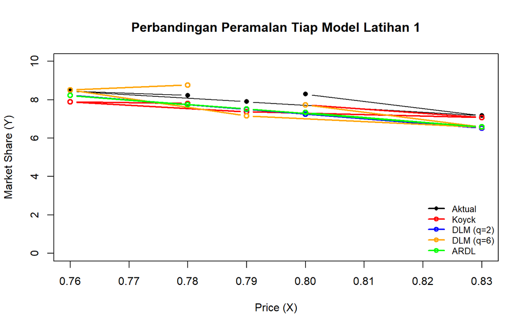

```r
par(mfrow=c(1,1))

plot(mkt_test$Price, mkt_test$MarketShare, type="b", col="black", pch=16,
     ylim=c(0,10), xlab="Price (X)", ylab="Market Share (Y)",
     main="Perbandingan Peramalan Tiap Model Latihan 1")

lines(mkt_test$Price, fc_koyck$forecasts, col="red", type="b", lwd=2)
lines(mkt_test$Price, fc_dlm_2$forecasts, col="blue", type="b", lwd=2)
lines(mkt_test$Price, fc_dlm_opt$forecasts, col="orange", type="b", lwd=2)
lines(mkt_test$Price, fc_ardl$forecasts, col="green", type="b", lwd=2)

legend("bottomright", legend=c("Aktual", "Koyck", "DLM (q=2)", "DLM (q=6)", "ARDL"),
       col=c("black", "red", "blue", "orange", "green"),
       lty=1, lwd=2, pch=c(16, 1, 1, 1, 1), bty="n", cex=0.8)
```

# Nomor 2: Sales vs Advertising

## 1. Impor & Pembagian Data

```r
dt_sales <- data.frame(
  Year = 1975:2014,
  Sales = c(11.7, 12.0, 12.3, 12.8, 13.1, 13.6, 13.9, 14.4, 14.7, 15.3,
            15.5, 15.8, 16.1, 16.6, 16.9, 16.7, 16.9, 17.4, 17.6, 17.9,
            18.0, 17.9, 18.0, 18.2, 18.2, 18.3, 18.6, 19.2, 19.3, 19.5,
            19.2, 19.3, 19.5, 20.0, 20.0, 19.9, 19.8, 19.9, 20.2, 21.0),
  Advertising = c(9.4, 9.6, 10.0, 10.4, 10.8, 10.9, 11.7, 12.2, 12.5, 12.9,
                  13.0, 13.2, 13.8, 14.2, 14.6, 14.4, 15.0, 15.4, 15.7, 15.9,
                  15.9, 16.0, 16.3, 16.2, 16.8, 17.3, 17.6, 18.1, 18.3, 18.5,
                  18.7, 18.9, 19.2, 20.0, 20.0, 20.3, 20.4, 21.0, 21.5, 22.1)
)

# Splitting 80% Train (32 data), 20% Test (8 data)
sales_train <- dt_sales[1:32,]
sales_test <- dt_sales[33:40,]
```

## 2. Pemodelan ARDL

```r
mdl_ardl_sales <- ardlDlm(formula = Sales ~ Advertising,
                          data = sales_train, p = 1, q = 1)
summary(mdl_ardl_sales)
```

```
##
## Time series regression with "ts" data:
## Start = 2, End = 32
##
## Call:
## dynlm(formula = as.formula(model.text), data = data)
##
## Residuals:
##      Min       1Q   Median       3Q      Max
## -0.42212 -0.13934  0.00585  0.09313  0.33270
##
## Coefficients:
##               Estimate Std. Error t value Pr(>|t|)
## (Intercept)    1.30304    0.47500   2.743   0.0107 *
## Advertising.t  0.30844    0.15564   1.982   0.0578 .
## Advertising.1 -0.20644    0.17382  -1.188   0.2453
## Sales.1        0.83951    0.09995   8.399  5.2e-09 ***
## ---
## Signif. codes:  0 '***' 0.001 '**' 0.01 '*' 0.05 '.' 0.1 ' ' 1
##
## Residual standard error: 0.1791 on 27 degrees of freedom
## Multiple R-squared:  0.9943, Adjusted R-squared:  0.9937
## F-statistic:  1575 on 3 and 27 DF,  p-value: < 2.2e-16
```

Berdasarkan output di atas, taksiran parameternya menghasilkan model dinamis sebagai berikut:
$$\hat{Y_t} = 1.30304
+ 0.30844X_t - 0.20644X_{t-1} + 0.83951Y_{t-1}$$

Persamaan ini memberikan landasan teori mengenai lagged effect dari suatu strategi pemasaran. Dampak investasi iklan terhadap sales terdistribusi lintas waktu. Lonjakan tajam di penjualan dipicu tidak hanya oleh anggaran iklan masif pada periode saat ini ($X_t$), namun dikalibrasi ulang oleh pergerakan investasi iklan sebelumnya ($X_{t-1}$) dan posisi basis penjualan yang sudah dikuasai di masa lalu ($Y_{t-1}$).

```r
# Prediksi 8 periode ke depan
fc_sales <- forecast(model = mdl_ardl_sales, x = sales_test$Advertising, h = 8)

# Perhitungan manual MAPE
mape_sales <- mean(abs((sales_test$Sales - fc_sales$forecasts) / sales_test$Sales)) * 100
cat("MAPE Model ARDL (1,1):", mape_sales, "%\n")
```

```
## MAPE Model ARDL (1,1): 1.905123 %
```

## 3. Penentuan Lag Optimum

```r
opt_sales <- ardlBoundOrders(data = data.frame(dt_sales), ic = "AIC",
                             formula = Sales ~ Advertising,
                             max.p = 6, max.q = 6)
opt_sales
```

```
## $p
##   Advertising
## 1           6
##
## $q
## [1] 1
##
## $Stat.table
##            q = 1      q = 2      q = 3      q = 4     q = 5      q = 6
## p = 1 -15.008746 -11.952031 -11.702811 -10.455610 -7.474346 -10.190508
## p = 2 -13.773954 -12.129560 -11.273832  -9.787319 -6.623348  -8.740430
## p = 3  -8.848612  -8.848612 -12.443867 -10.393720 -7.139840  -9.693082
## p = 4 -12.022451 -10.663941 -10.663941  -8.669246 -5.388398  -8.000189
## p = 5  -6.455663  -4.517684  -6.129877  -6.129877 -5.821876  -9.506366
## p = 6 -11.513095  -9.679368 -10.603965  -8.746914 -8.746914  -8.630625
##
## $min.Stat
## [1] -15.00875
```

```r
# Ekstraksi kombinasi parameter yang memberikan AIC terkecil
min_p2 <- c()
for(i in 1:6){
  min_p2[i] <- min(opt_sales$Stat.table[[i]])
}
q_opt2 <- which(min_p2 == min(min_p2, na.rm = TRUE))
p_opt2 <- which(opt_sales$Stat.table[[q_opt2]] ==
                min(opt_sales$Stat.table[[q_opt2]], na.rm = TRUE))

data.frame("q_optimum" = q_opt2, "p_optimum" = p_opt2,
           "AIC_Terkecil" = opt_sales$min.Stat)
```

```
##   q_optimum p_optimum AIC_Terkecil
## 1         1         1    -15.00875
```

Tabel ekstraksi hasil uji merangkum komputasi iteratif penyeleksian orde ARDL. Kombinasi lag spesifik yang mencetak nilai minimal Akaike Information Criterion (AIC) sebesar -15.00875 secara definitif diraih saat penentuan lag regresor $p = 1$ dan variabel lag terikat $q = 1$. Temuan analitik ini memvalidasi suatu kaidah penting: kompleksitas ruang dimensi model tidak berbanding lurus dengan utilitas prediksi. Menambah jumlah lag di atas ordo satu (first-order delay) terbukti gagal memberikan kontribusi perbaikan model regresi yang berarti terhadap variabilitas data historis penjualan. Oleh karenanya, struktur arsitektur model ARDL(1,1) yang diajukan di awal dikonfirmasi sebagai kerangka kerja regresi deret waktu yang paling fundamental, proporsional, dan superior dari segi efisiensi informasional.